# Value Functions & Bellman Equations

### Policies and Value Functions

Almost all reinforcement learning algorithms involve estimating value functions—functions of states (or of state–action pairs) that estimate how good it is for the agent to be in a given state (or how good it is to perform a given action in a given state).  
The notion of “how good” here is defined in terms of future rewards that can be expected, or, to be precise, in terms of expected return. Of course the rewards the agent can expect to receive in the future depend on what actions it will take.  
Accordingly, value functions are defined with respect to particular ways of acting, called policies.  
The value function of a state s under a policy $\pi$, denoted $v_{\pi}(s)$, is the expected return when starting in $s$ and following $\pi$ thereafter.

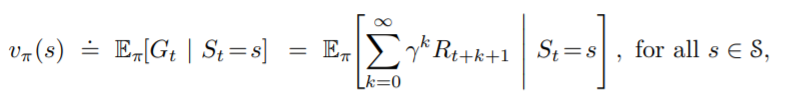

Similarly, we define the value of taking action a in state s under a policy $\pi$, denoted $q_{\pi}(s, a)$, as the expected return starting from $s$, taking the action $a$, and thereafter following policy $\pi$:

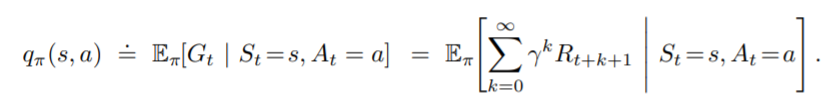

We call $q_{\pi}$ the action-value function for policy $\pi$.

### Bellman Equation for $v_{\pi}$

It expresses a relationship between the value of a state and the values of its successor states.

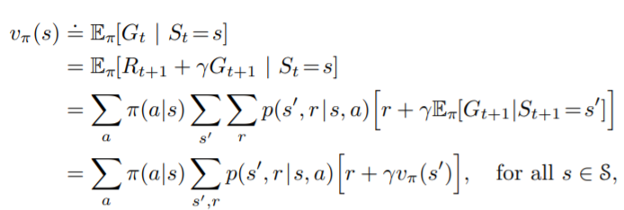

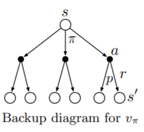

#### Bellman Equations for a small grid problem - 1

The cells of the grid correspond to the states of the environment. At each cell, four actions are possible: north, south, east, and west, which deterministically cause the agent to move one cell in the respective direction on the grid.  
Actions that would take the agent off the grid leave its location unchanged, but also result in a reward of -1.  
Other actions result in a reward of 0, except those that move the agent out of the states '1' and '4'.  
From state '1', all four actions yield a reward of +10 and take the agent to '3'.  
From state '4', all actions yield a reward of +5 and take the agent to '2'.

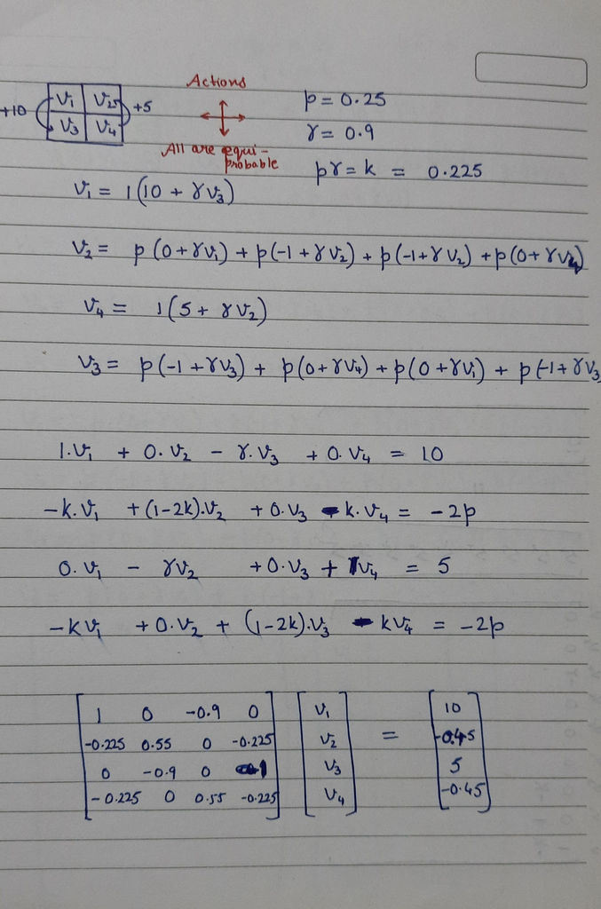

#### Bellman Equations for a small grid problem - 2

$p=0.25$  
$\gamma=0.9$

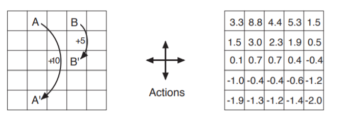

```python
import numpy as np
p = 0.25
g = 0.9
# left dr = 0, dc = -1
# right dr = 0, dc = +1
# up dr = -1, dc = 0
# down dr = +1, dc = 0
def nextStateReward(r,c,dr,dc):
    if((r==0) and (c==1)): ## At A, then move to A'
        nr = 4
        nc = 1
        R = 10
        return (nr,nc,R)
    elif((r==0) and (c==3)):
        nr = 2
        nc = 3
        R = 5
        return (nr,nc,R)
    else:
        nr = r + dr
        nc = c + dc
        if((nr==-1) or (nr==5)):
            nr = r
            R = -1
            return (nr,nc,R)
        elif((nc==-1) or (nc==5)):
            nc = c
            R = -1
            return (nr,nc,R)
        else:
            R = 0
            return (nr,nc,R)


def toInd(r,c):
    return (5*r+c)

A = np.zeros((25,25))
B = np.zeros(25)

for r in range(0,5):
    for c in range(0,5):
        ind = toInd(r,c)
        A[ind,ind] = 1
        (nr,nc,R) = nextStateReward(r,c,0,-1)
        indn = toInd(nr,nc)
        A[ind,indn] +=(-g*p)
        B[ind] += p*R

        (nr,nc,R) = nextStateReward(r,c,0,1)
        indn = toInd(nr,nc)
        A[ind,indn] +=(-g*p)
        B[ind] += p*R

        (nr,nc,R) = nextStateReward(r,c,-1,0)
        indn = toInd(nr,nc)
        A[ind,indn] +=(-g*p)
        B[ind] += p*R

        (nr,nc,R) = nextStateReward(r,c,1,0)
        indn = toInd(nr,nc)
        A[ind,indn] +=(-g*p)
        B[ind] += p*R
```

```python
import pandas as pd
dfA = pd.DataFrame(A)
display(dfA)
```

|  | 0 | 1 | 2 | 3 | 4 | 5 | 6 | 7 | 8 | 9 | ... | 15 | 16 | 17 | 18 | 19 | 20 | 21 | 22 | 23 | 24 |
| --- | --- | --- | --- | --- | --- | --- | --- | --- | --- | --- | --- | --- | --- | --- | --- | --- | --- | --- | --- | --- | --- |
| 0 | 0.550 | -0.225 | 0.000 | 0.000 | 0.000 | -0.225 | 0.000 | 0.000 | 0.000 | 0.000 | ... | 0.000 | 0.000 | 0.000 | 0.000 | 0.000 | 0.000 | 0.000 | 0.000 | 0.000 | 0.000 |
| 1 | 0.000 | 1.000 | 0.000 | 0.000 | 0.000 | 0.000 | 0.000 | 0.000 | 0.000 | 0.000 | ... | 0.000 | 0.000 | 0.000 | 0.000 | 0.000 | 0.000 | -0.900 | 0.000 | 0.000 | 0.000 |
| 2 | 0.000 | -0.225 | 0.775 | -0.225 | 0.000 | 0.000 | 0.000 | -0.225 | 0.000 | 0.000 | ... | 0.000 | 0.000 | 0.000 | 0.000 | 0.000 | 0.000 | 0.000 | 0.000 | 0.000 | 0.000 |
| 3 | 0.000 | 0.000 | 0.000 | 1.000 | 0.000 | 0.000 | 0.000 | 0.000 | 0.000 | 0.000 | ... | 0.000 | 0.000 | 0.000 | 0.000 | 0.000 | 0.000 | 0.000 | 0.000 | 0.000 | 0.000 |
| 4 | 0.000 | 0.000 | 0.000 | -0.225 | 0.550 | 0.000 | 0.000 | 0.000 | 0.000 | -0.225 | ... | 0.000 | 0.000 | 0.000 | 0.000 | 0.000 | 0.000 | 0.000 | 0.000 | 0.000 | 0.000 |
| 5 | -0.225 | 0.000 | 0.000 | 0.000 | 0.000 | 0.775 | -0.225 | 0.000 | 0.000 | 0.000 | ... | 0.000 | 0.000 | 0.000 | 0.000 | 0.000 | 0.000 | 0.000 | 0.000 | 0.000 | 0.000 |
| 6 | 0.000 | -0.225 | 0.000 | 0.000 | 0.000 | -0.225 | 1.000 | -0.225 | 0.000 | 0.000 | ... | 0.000 | 0.000 | 0.000 | 0.000 | 0.000 | 0.000 | 0.000 | 0.000 | 0.000 | 0.000 |
| 7 | 0.000 | 0.000 | -0.225 | 0.000 | 0.000 | 0.000 | -0.225 | 1.000 | -0.225 | 0.000 | ... | 0.000 | 0.000 | 0.000 | 0.000 | 0.000 | 0.000 | 0.000 | 0.000 | 0.000 | 0.000 |
| 8 | 0.000 | 0.000 | 0.000 | -0.225 | 0.000 | 0.000 | 0.000 | -0.225 | 1.000 | -0.225 | ... | 0.000 | 0.000 | 0.000 | 0.000 | 0.000 | 0.000 | 0.000 | 0.000 | 0.000 | 0.000 |
| 9 | 0.000 | 0.000 | 0.000 | 0.000 | -0.225 | 0.000 | 0.000 | 0.000 | -0.225 | 0.775 | ... | 0.000 | 0.000 | 0.000 | 0.000 | 0.000 | 0.000 | 0.000 | 0.000 | 0.000 | 0.000 |
| 10 | 0.000 | 0.000 | 0.000 | 0.000 | 0.000 | -0.225 | 0.000 | 0.000 | 0.000 | 0.000 | ... | -0.225 | 0.000 | 0.000 | 0.000 | 0.000 | 0.000 | 0.000 | 0.000 | 0.000 | 0.000 |
| 11 | 0.000 | 0.000 | 0.000 | 0.000 | 0.000 | 0.000 | -0.225 | 0.000 | 0.000 | 0.000 | ... | 0.000 | -0.225 | 0.000 | 0.000 | 0.000 | 0.000 | 0.000 | 0.000 | 0.000 | 0.000 |
| 12 | 0.000 | 0.000 | 0.000 | 0.000 | 0.000 | 0.000 | 0.000 | -0.225 | 0.000 | 0.000 | ... | 0.000 | 0.000 | -0.225 | 0.000 | 0.000 | 0.000 | 0.000 | 0.000 | 0.000 | 0.000 |
| 13 | 0.000 | 0.000 | 0.000 | 0.000 | 0.000 | 0.000 | 0.000 | 0.000 | -0.225 | 0.000 | ... | 0.000 | 0.000 | 0.000 | -0.225 | 0.000 | 0.000 | 0.000 | 0.000 | 0.000 | 0.000 |
| 14 | 0.000 | 0.000 | 0.000 | 0.000 | 0.000 | 0.000 | 0.000 | 0.000 | 0.000 | -0.225 | ... | 0.000 | 0.000 | 0.000 | 0.000 | -0.225 | 0.000 | 0.000 | 0.000 | 0.000 | 0.000 |
| 15 | 0.000 | 0.000 | 0.000 | 0.000 | 0.000 | 0.000 | 0.000 | 0.000 | 0.000 | 0.000 | ... | 0.775 | -0.225 | 0.000 | 0.000 | 0.000 | -0.225 | 0.000 | 0.000 | 0.000 | 0.000 |
| 16 | 0.000 | 0.000 | 0.000 | 0.000 | 0.000 | 0.000 | 0.000 | 0.000 | 0.000 | 0.000 | ... | -0.225 | 1.000 | -0.225 | 0.000 | 0.000 | 0.000 | -0.225 | 0.000 | 0.000 | 0.000 |
| 17 | 0.000 | 0.000 | 0.000 | 0.000 | 0.000 | 0.000 | 0.000 | 0.000 | 0.000 | 0.000 | ... | 0.000 | -0.225 | 1.000 | -0.225 | 0.000 | 0.000 | 0.000 | -0.225 | 0.000 | 0.000 |
| 18 | 0.000 | 0.000 | 0.000 | 0.000 | 0.000 | 0.000 | 0.000 | 0.000 | 0.000 | 0.000 | ... | 0.000 | 0.000 | -0.225 | 1.000 | -0.225 | 0.000 | 0.000 | 0.000 | -0.225 | 0.000 |
| 19 | 0.000 | 0.000 | 0.000 | 0.000 | 0.000 | 0.000 | 0.000 | 0.000 | 0.000 | 0.000 | ... | 0.000 | 0.000 | 0.000 | -0.225 | 0.775 | 0.000 | 0.000 | 0.000 | 0.000 | -0.225 |
| 20 | 0.000 | 0.000 | 0.000 | 0.000 | 0.000 | 0.000 | 0.000 | 0.000 | 0.000 | 0.000 | ... | -0.225 | 0.000 | 0.000 | 0.000 | 0.000 | 0.550 | -0.225 | 0.000 | 0.000 | 0.000 |
| 21 | 0.000 | 0.000 | 0.000 | 0.000 | 0.000 | 0.000 | 0.000 | 0.000 | 0.000 | 0.000 | ... | 0.000 | -0.225 | 0.000 | 0.000 | 0.000 | -0.225 | 0.775 | -0.225 | 0.000 | 0.000 |
| 22 | 0.000 | 0.000 | 0.000 | 0.000 | 0.000 | 0.000 | 0.000 | 0.000 | 0.000 | 0.000 | ... | 0.000 | 0.000 | -0.225 | 0.000 | 0.000 | 0.000 | -0.225 | 0.775 | -0.225 | 0.000 |
| 23 | 0.000 | 0.000 | 0.000 | 0.000 | 0.000 | 0.000 | 0.000 | 0.000 | 0.000 | 0.000 | ... | 0.000 | 0.000 | 0.000 | -0.225 | 0.000 | 0.000 | 0.000 | -0.225 | 0.775 | -0.225 |
| 24 | 0.000 | 0.000 | 0.000 | 0.000 | 0.000 | 0.000 | 0.000 | 0.000 | 0.000 | 0.000 | ... | 0.000 | 0.000 | 0.000 | 0.000 | -0.225 | 0.000 | 0.000 | 0.000 | -0.225 | 0.550 |

25 rows × 25 columns

```python
dfB = pd.DataFrame(B)
display(dfB)
```

|  | 0 |
| --- | --- |
| 0 | -0.50 |
| 1 | 10.00 |
| 2 | -0.25 |
| 3 | 5.00 |
| 4 | -0.50 |
| 5 | -0.25 |
| 6 | 0.00 |
| 7 | 0.00 |
| 8 | 0.00 |
| 9 | -0.25 |
| 10 | -0.25 |
| 11 | 0.00 |
| 12 | 0.00 |
| 13 | 0.00 |
| 14 | -0.25 |
| 15 | -0.25 |
| 16 | 0.00 |
| 17 | 0.00 |
| 18 | 0.00 |
| 19 | -0.25 |
| 20 | -0.50 |
| 21 | -0.25 |
| 22 | -0.25 |
| 23 | -0.25 |
| 24 | -0.50 |

```python
from scipy.linalg import solve
x = solve(A,B)
x = np.round(x,1).reshape(5,5)
dfX = pd.DataFrame(x)
display(dfX)
```

|  | 0 | 1 | 2 | 3 | 4 |
| --- | --- | --- | --- | --- | --- |
| 0 | 3.3 | 8.8 | 4.4 | 5.3 | 1.5 |
| 1 | 1.5 | 3.0 | 2.3 | 1.9 | 0.5 |
| 2 | 0.1 | 0.7 | 0.7 | 0.4 | -0.4 |
| 3 | -1.0 | -0.4 | -0.4 | -0.6 | -1.2 |
| 4 | -1.9 | -1.3 | -1.2 | -1.4 | -2.0 |

### Optimal Policies and Optimal Value Function

Solving a reinforcement learning task means, roughly, finding a policy that achieves a lot of reward over the long run.  
For finite MDPs, we can precisely define an optimal policy in the following way. Value functions define a partial ordering over policies. A policy $\pi$ is defined to be better than or equal to a policy $\pi'$ if its expected return is greater than or equal to that of $\pi'$ for all states.  
In other words,$\pi \ge \pi'$ if and only if $v_{\pi}(s) \ge v_{\pi'}(s)$ for all $s\in S$.  
There is always at least one policy that is better than or equal to all other policies.  
This is an optimal policy. Although there may be more than one, we denote all the optimal policies by $\pi_{*}$.  
They share the same state-value function, called the optimal state-value function, denoted $v_{*}$, and defined as

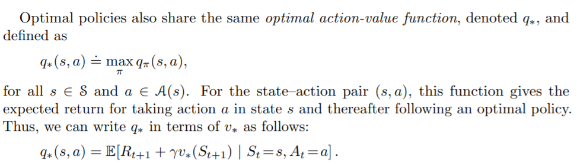

#### Bellman Optimality Equations

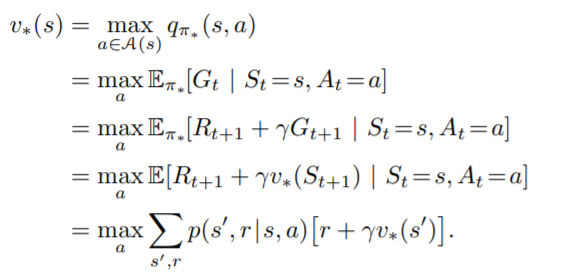

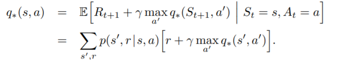

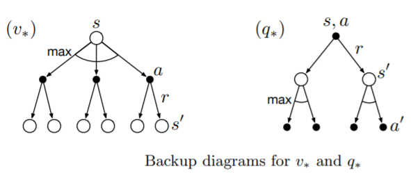

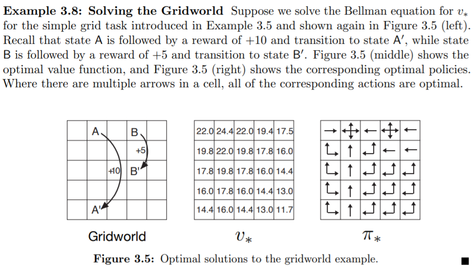

Explicitly solving Bellman Optimality Equations will involve exhaustive search for all possibilities and calculating probabilities. And will involve computational power not practically feasible.  
In reinforcement learning one typically has to settle for approximate solutions.

### References

https://mitpress.mit.edu/books/reinforcement-learning  
https://www.coursera.org/specializations/reinforcement-learning